# Project Python Foundations: FoodHub Data Analysis

### **Question 10**: What is the mean order delivery time? [1 mark]

```python
# Calculate the mean delivery time
mean_delivery_time = df['delivery_time'].mean()

print(f"The mean delivery time for all orders is: {mean_delivery_time:.2f} minutes")
```

```
The mean delivery time for all orders is: 24.16 minutes
```

#### **Observations:**

The average delivery time is 24.16 minutes, positioning FoodHub as a competitive player in the market.

### **Question 11:** The company has decided to give 20% discount vouchers to the top 3 most frequent customers. Find the IDs of these customers and the number of orders they placed. [1 mark]

```python
# Find the top 3 most frequent customers
top_3_customers = df['customer_id'].value_counts().head(3)

print("Top 3 Most Frequent Customers (Voucher Recipients):")
print(top_3_customers)
```

```
Top 3 Most Frequent Customers (Voucher Recipients):
customer_id
52832    13
47440    10
83287     9
Name: count, dtype: int64
```

### **Question 12**: Perform a multivariate analysis to explore relationships between the important variables in the dataset. (It is a good idea to explore relations between numerical variables as well as relations between numerical and categorical variables) [10 marks]

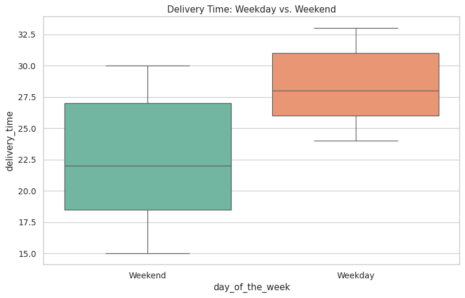

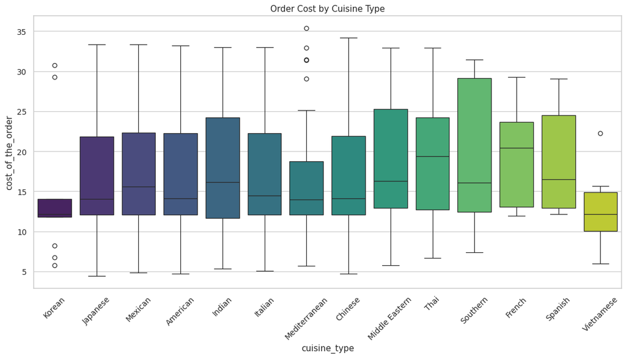

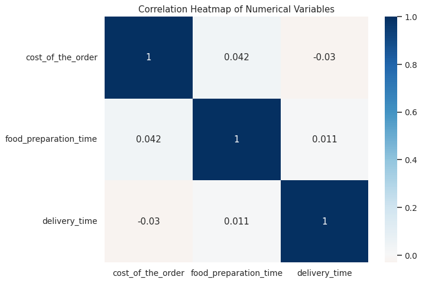

```python
import matplotlib.pyplot as plt
import seaborn as sns

# Relationship between Day of the Week and Delivery Time
plt.figure(figsize=(10, 6))
sns.boxplot(data=df, x='day_of_the_week', y='delivery_time', hue='day_of_the_week', palette='Set2', legend=False)
plt.title('Delivery Time: Weekday vs. Weekend')
plt.show()

# Relationship between Cuisine Type and Cost of Order
plt.figure(figsize=(15, 7))
sns.boxplot(data=df, x='cuisine_type', y='cost_of_the_order', hue='cuisine_type', palette='viridis', legend=False)
plt.title('Order Cost by Cuisine Type')
plt.xticks(rotation=45)
plt.show()

# Calculate the correlation matrix
corr_matrix = df[['cost_of_the_order', 'food_preparation_time', 'delivery_time']].corr()

# Plot the heatmap
plt.figure(figsize=(8, 6))
sns.heatmap(corr_matrix, annot=True, cmap='RdBu', center=0)
plt.title('Correlation Heatmap of Numerical Variables')
plt.show()
```

### **Question 13:** The company wants to provide a promotional offer in the advertisement of the restaurants. The condition to get the offer is that the restaurants must have a rating count of more than 50 and the average rating should be greater than 4. Find the restaurants fulfilling the criteria to get the promotional offer. [3 marks]

```python
# Filter, Group, and Aggregate in one clean block
qualified_restaurants = (
    df[df['rating'] != 'Not given']                       # 1. Drop 'Not given'
    .assign(rating = lambda x: x['rating'].astype(int))   # 2. Convert to numbers
    .groupby('restaurant_name')['rating']                 # 3. Group by restaurant
    .agg(['count', 'mean'])                               # 4. Get count and average
    .query('count > 50 and mean > 4')                     # 5. Filter for the offer
    .reset_index()
)

print("Restaurants Qualified for the Promotional Offer:")
qualified_restaurants
```

```
Restaurants Qualified for the Promotional Offer:
```

|  | restaurant_name | count | mean |
| --- | --- | --- | --- |
| 0 | Blue Ribbon Fried Chicken | 64 | 4.328125 |
| 1 | Blue Ribbon Sushi | 73 | 4.219178 |
| 2 | Shake Shack | 133 | 4.278195 |
| 3 | The Meatball Shop | 84 | 4.511905 |

#### **Observations:**

Only four restaurants meet both criteria (count > 50 and mean rating > 4.0).

1. The Meatball Shop has the highest average customer satisfaction (4.51), making it the strongest performer in terms of rating quality.
2. Shake Shack stands out for having the largest number of ratings (133), indicating very high popularity/volume while still maintaining a strong average above 4.27.
3. The two Blue Ribbon locations (Fried Chicken and Sushi) also qualify comfortably, showing consistent above-average performance.
4. These four restaurants appear to be the most reliable choices for featuring in the promotional campaign, combining both high volume of feedback and strong customer approval.

### **Question 14:** The company charges the restaurant 25% on the orders having cost greater than 20 dollars and 15% on the orders having cost greater than 5 dollars. Find the net revenue generated by the company across all orders. [3 marks]

```python
# Create a function to calculate revenue based on the cost
def calculate_revenue(cost):
    if cost > 20:
        return cost * 0.25
    elif cost > 5:
        return cost * 0.15
    else:
        return 0

# Apply the function to each order cost and create a new column
df['revenue'] = df['cost_of_the_order'].apply(calculate_revenue)

# Sum the revenue column to find the total
total_net_revenue = df['revenue'].sum()

print(f"The net revenue generated by the company is: ${total_net_revenue:.2f}")
```

```
The net revenue generated by the company is: $6166.30
```

**Observations:**

The tiered commission structure generates approximately $6,166.30 in total net revenue.

By applying a higher 25% fee to orders over $20, the company successfully capitalizes on high-value transactions, which account for nearly 30% of total volume.

### **Question 15:** The company wants to analyze the total time required to deliver the food. What percentage of orders take more than 60 minutes to get delivered from the time the order is placed? (The food has to be prepared and then delivered.) [2 marks]

```python
# import pandas as pd

# Read the data from foodhub_order.csv
df = pd.read_csv('/content/foodhub_order.csv')

# Create the total_time column by adding prep time and delivery time
df['total_time'] = df['food_preparation_time'] + df['delivery_time']

# Calculate the percentage of orders taking more than 60 minutes
# (mean of boolean gives fraction → ×100 = percentage)
percent_over_60 = (df['total_time'] > 60).mean() * 100

# Print the result formatted to 2 decimal places
print(f"Percentage of orders taking more than 60 minutes: {percent_over_60:.2f}%")
```

```
Percentage of orders taking more than 60 minutes: 10.54%
```

#### Observations:

- Only 10.54% of orders take more than 60 minutes from preparation start to delivery completion.
- The vast majority of orders (~89.46%) are completed (prepared + delivered) within 60 minutes.
- This indicates good overall timeliness, but the 1-in-10 delayed orders still represent a significant opportunity for service improvement.

### **Question 16:** The company wants to analyze the delivery time of the orders on weekdays and weekends. How does the mean delivery time vary during weekdays and weekends? [2 marks]

```python
# Direct "Weekday" / "Weekend" labels already exist
if 'day_of_the_week' in df.columns:
    mean_delivery = df.groupby('day_of_the_week')['delivery_time'].mean().round(2)

    print("Mean Delivery Time by Day Type:")
    print(mean_delivery)
    print("\nDifference (Weekend - Weekday):",
          round(mean_delivery.get('Weekend', 0) - mean_delivery.get('Weekday', 0), 2), "minutes")
```

```
Mean Delivery Time by Day Type:
day_of_the_week
Weekday    28.34
Weekend    22.47
Name: delivery_time, dtype: float64

Difference (Weekend - Weekday): -5.87 minutes
```

#### **Observations**:

Delivery times are substantially faster on weekends (22.47 min) than on weekdays (28.34 min), with an average improvement of 5.87 minutes (~21% faster).

This indicates smoother logistics and potentially higher customer satisfaction during weekend periods, highlighting an opportunity to understand and apply weekend efficiencies to weekday operations.

## **Conclusion**

FoodHub shows strong overall performance: only 10.54% of orders exceed 60 minutes total time. Deliveries are noticeably faster on weekends (22.47 min) than weekdays (28.34 min), a 5.87-minute (21%) improvement, highlighting smoother weekend operations.

## **Recommendations**

- Focus on weekday improvements (e.g., extra couriers during peak hours, better routing).
- Replicate weekend efficiencies (traffic/staffing advantages) on weekdays where possible.
- Target the ~10% long-wait orders with root-cause analysis and proactive compensations.
- Set more realistic ETAs on weekdays and promote faster weekend service.
- Monitor trends and test changes to reduce delays and boost satisfaction.

### **Question 17:** What are your conclusions from the analysis? What recommendations would you like to share to help improve the business? (You can use cuisine type and feedback ratings to drive your business recommendations.) [6 marks]

### **Conclusions:**

- American cuisine clearly dominates on weekends, with 415 orders — making it the most popular cuisine choice when people are more likely to order for leisure, family meals, or social occasions.
- A very high 38.78% of orders (736 orders) have no rating ("Not given"), which is a major data quality and feedback gap. This means the company is currently missing customer feedback on nearly 4 out of every 10 orders.
- Combined with earlier findings: Only ~10.5% of orders take >60 minutes total time → overall timeliness is acceptable Weekend deliveries are ~6 minutes faster than weekdays → weekend experience is noticeably smoother
- However, the lack of ratings severely limits the ability to understand true customer satisfaction, identify problem restaurants/cuisines, or measure the real impact of delivery speed on experience.
- The business currently has a good operational foundation (fast weekends, low very-long-wait orders), but suffers from very poor feedback capture, which hides both strengths and pain points.